# T1CP4

18 de julho de 2016

```r
library(dplyr, warn.conflicts = FALSE)
```

```r
library(ggplot2)
source('leitor.R')
theme_set(theme_bw())
```

## Dados

Os dados que são a base da análise descrevem os gastos realizados pelos deputados brasileiros no ano de 2016. Estes dados são abertos e disponibilizados pela própria câmara legislativa e podem ser encontrados neste link: http://www2.camara.leg.br/transparencia/cota-para-exercicio-da-atividade-parlamentar/dados-abertos-cota-parlamentar Para conhecer o que está descrito no conjunto de dados, basta acessar este outro link: http://www2.camara.leg.br/transparencia/cota-para-exercicio-da-atividade-parlamentar/dados-abertos-cota-parlamentar

```r
dados = ler_gastos()
str(dados)
```

```
## Classes 'tbl_df', 'tbl' and 'data.frame':    149485 obs. of  29 variables:
##  $ sgPartido                : Factor w/ 28 levels "DEM","PCdoB",..: 1 1 1 1 1 1 1 1 1 1 ...
##  $ numMes                   : int  1 3 2 3 2 3 2 4 5 2 ...
##  $ txtCNPJCPF               : chr  "05939467000115" "05939467000115" "05939467000115" "02341470000144" ...
##  $ vlrGlosa                 : num  6 1.6 0 9.85 0 0 0 0 0 0 ...
##  $ txNomeParlamentar        : Factor w/ 572 levels "ABEL MESQUITA JR.",..: 1 1 1 1 1 1 1 1 1 1 ...
##  $ sgUF                     : Factor w/ 27 levels "AC","AL","AM",..: 22 22 22 22 22 22 22 22 22 22 ...
##  $ nuCarteiraParlamentar    : int  1 1 1 1 1 1 1 1 1 1 ...
##  $ vlrDocumento             : num  37.4 38.8 33.3 464.3 112.1 ...
##  $ nuDeputadoId             : int  3074 3074 3074 3074 3074 3074 3074 3074 3074 3074 ...
##  $ numSubCota               : int  1 1 1 1 1 3 3 3 3 3 ...
##  $ txtDescricaoEspecificacao: chr  NA NA NA NA ...
##  $ datEmissao               : POSIXct, format: "2016-02-15 00:00:00" "2016-03-12 00:00:00" ...
##  $ codLegislatura           : int  55 55 55 55 55 55 55 55 55 55 ...
##  $ numParcela               : int  0 0 0 0 0 0 0 0 0 0 ...
##  $ txtDescricao             : chr  "MANUTENÇÃO DE ESCRITÓRIO DE APOIO À ATIVIDADE PARLAMENTAR" "MANUTENÇÃO DE ESCRITÓRIO DE APOIO À ATIVIDADE PARLAMENTAR" "MANUTENÇÃO DE ESCRITÓRIO DE APOIO À ATIVIDADE PARLAMENTAR" "MANUTENÇÃO DE ESCRITÓRIO DE APOIO À ATIVIDADE PARLAMENTAR" ...
##  $ txtNumero                : chr  "146439" "146439" "YO6FO21914" "000004221" ...
##  $ numEspecificacaoSubCota  : int  0 0 0 0 0 1 1 1 1 1 ...
##  $ txtFornecedor            : chr  "COMPANHIA DE AGUAS E ESGOTOS DE RORAIMA" "COMPANHIA DE AGUAS E ESGOTOS DE RORAIMA" "COMPANHIA DE AGUAS E ESGOTOS DE RORAIMA" "ELETROBRAS DISTRIBUIÇÃO RORAIMA" ...
##  $ numLote                  : int  1268870 1282185 1268878 1289623 1282183 1278448 1268791 1289609 1295137 1268790 ...
##  $ indTipoDocumento         : Factor w/ 4 levels "0","1","2","3": 1 1 1 1 1 1 1 1 1 1 ...
##  $ numAno                   : int  2016 2016 2016 2016 2016 2016 2016 2016 2016 2016 ...
##  $ numRessarcimento         : int  5369 5417 5369 5442 5417 5413 5369 5441 5466 5367 ...
##  $ vlrLiquido               : num  31.4 37.2 33.3 454.5 112.1 ...
##  $ ideDocumento             : int  5928744 5970849 5928732 5993742 5970856 5959453 5928619 5986310 6011374 5928626 ...
##  $ ideCadastro              : int  178957 178957 178957 178957 178957 178957 178957 178957 178957 178957 ...
##  $ nuLegislatura            : int  2015 2015 2015 2015 2015 2015 2015 2015 2015 2015 ...
##  $ txtPassageiro            : chr  NA NA NA NA ...
##  $ txtTrecho                : chr  NA NA NA NA ...
##  $ vlrRestituicao           : chr  NA NA NA NA ...
```

## Número de deputados por partido

Antes de tudo é bom termos algumas informações, como a quantidade de deputados por partido, para conhecer os maiores/menores partidos do país.

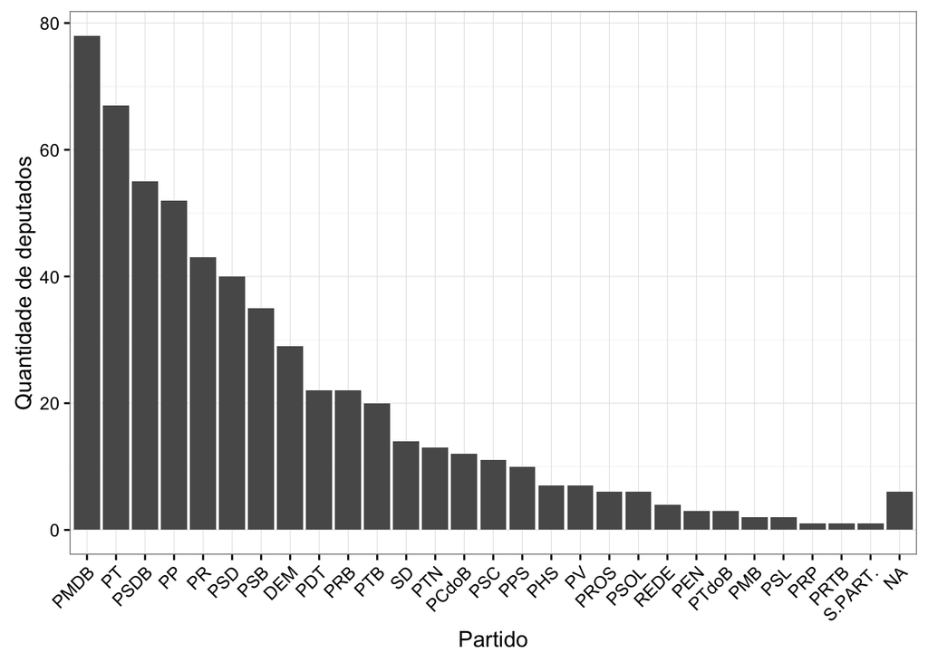

```r
qtdPorPartido = dados %>%
  select(txNomeParlamentar, sgPartido) %>%
  distinct() %>%
  group_by(sgPartido) %>%
  summarise(deputadosPorPartido = n())

ggplot(qtdPorPartido, mapping = aes(x = reorder(sgPartido, -deputadosPorPartido), y= deputadosPorPartido)) +
  geom_bar(stat="identity") +
  labs(x="Partido", y="Quantidade de deputados") +
  theme(axis.text.x = element_text(angle = 45, hjust = 1))
```

## Número de deputados por estado

Outra informação básica que nem sempre sabemos é a quantidade de deputados que temos em nosso estado. Sendo assim, abaixo encontramos um gráfico representando a quantidade de deputados por estado.

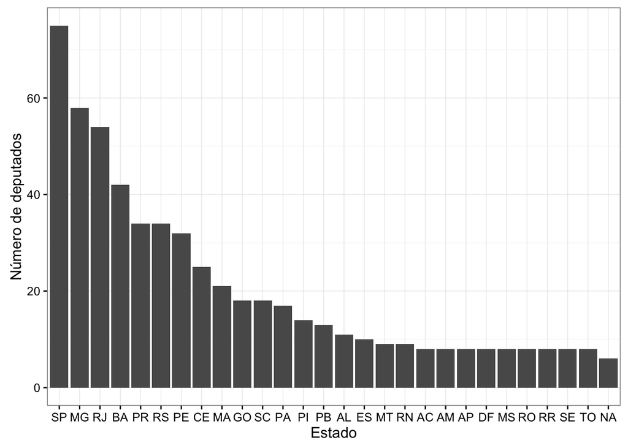

```r
qtdPorEstado = dados %>%
  select(txNomeParlamentar, sgUF) %>%
  distinct() %>%
  group_by(sgUF)%>%
  summarise(depPorEstado = n())

ggplot(qtdPorEstado) +
  geom_bar(stat="identity", mapping = aes(x = reorder(sgUF, -depPorEstado),
                         y = depPorEstado)) +
    labs(x='Estado', y='Número de deputados')
```

## Tipos possíveis de gastos

Nossos deputados dipõem de uma cota de valor para gastos próprios durante seu mandato. Estes são os possíveis tipos de gastos que cada um pode atribuir às suas despesas.

```r
tipoDeGastos = dados%>%
  select(txtDescricao, numSubCota)%>%
  unique()
  colnames(tipoDeGastos) = c("Despesa", "ID")
  print(tipoDeGastos %>% select(ID, Despesa))
```

```
## # A tibble: 18 x 2
##       ID                                                   Despesa
##    <int>                                                     <chr>
## 1      1 MANUTENÇÃO DE ESCRITÓRIO DE APOIO À ATIVIDADE PARLAMENTAR
## 2      3                             COMBUSTÍVEIS E LUBRIFICANTES.
## 3      4             CONSULTORIAS, PESQUISAS E TRABALHOS TÉCNICOS.
## 4      5                      DIVULGAÇÃO DA ATIVIDADE PARLAMENTAR.
## 5      8  SERVIÇO DE SEGURANÇA PRESTADO POR EMPRESA ESPECIALIZADA.
## 6     10                                                 TELEFONIA
## 7     11                                          SERVIÇOS POSTAIS
## 8    120             LOCAÇÃO OU FRETAMENTO DE VEÍCULOS AUTOMOTORES
## 9    999                                     Emissão Bilhete Aéreo
## 10     9                                          PASSAGENS AÉREAS
## 11    13                FORNECIMENTO DE ALIMENTAÇÃO DO PARLAMENTAR
## 12   122                 SERVIÇO DE TÁXI, PEDÁGIO E ESTACIONAMENTO
## 13    12                                 ASSINATURA DE PUBLICAÇÕES
## 14    14    HOSPEDAGEM ,EXCETO DO PARLAMENTAR NO DISTRITO FEDERAL.
## 15   123               PASSAGENS TERRESTRES, MARÍTIMAS OU FLUVIAIS
## 16   119                        LOCAÇÃO OU FRETAMENTO DE AERONAVES
## 17   121                      LOCAÇÃO OU FRETAMENTO DE EMBARCAÇÕES
## 18   137         PARTICIPAÇÃO EM CURSO, PALESTRA OU EVENTO SIMILAR
```

## Ordenando os gastos por tipo

Visto o leque de opções para atribuir gastos de dinheiro, quais serão as classes de despesas em que mais se tem valor atribuído?

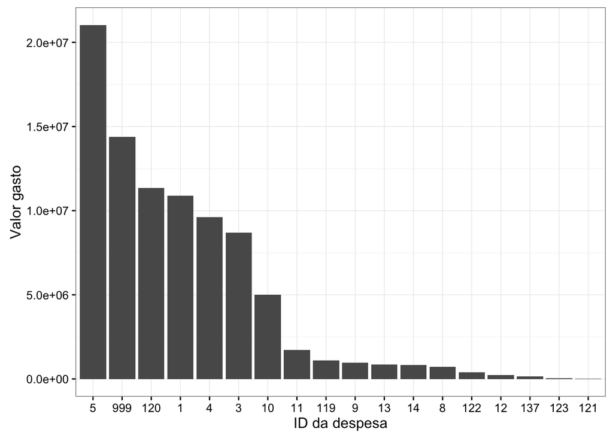

```r
gastosPorTipo = dados %>%
  select(numSubCota, vlrLiquido) %>%
  group_by(numSubCota) %>%
  summarise(vlrLiq = sum(vlrLiquido))

ggplot(gastosPorTipo) +
  geom_bar(stat="identity", mapping = aes(x = reorder(numSubCota, -vlrLiq),
                         y = vlrLiq)) +
    labs(x='ID da despesa', y='Valor gasto')
```

## Gastos que tem valores mais desiguais

Já este gráfico mostra as classes ou tipos de gastos que tem maior disparidade entre os valores atribuídos. Se destacam, com grande diferença quando comparado aos demais gastos, em primeiro lugar DIVULGAÇÃO DA ATIVIDADE PARLAMENTAR, em segundo lugar CONSULTORIAS, PESQUISAS E TRABALHOS TÉCNICOS e em terceiro lugar LOCAÇÃO OU FRETAMENTO DE AERONAVES.

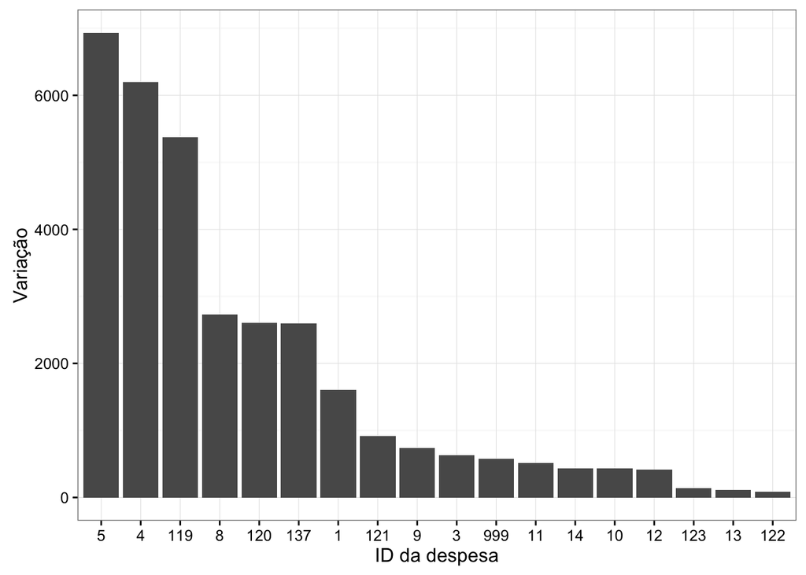

```r
desvioPadraoDosGastos = dados %>%
  select(numSubCota, vlrLiquido) %>%
  group_by(numSubCota) %>%
  summarise(desvio = sd(vlrLiquido))

ggplot(desvioPadraoDosGastos) +
  geom_bar(stat="identity", mapping = aes(x = reorder(numSubCota, -desvio),
                         y = desvio)) +
    labs(x='ID da despesa', y='Variação')
```

## Será que estados com menor número de deputados gastam mais que estados com maior quantidade de deputados?

Estando os estados ordenados por suas respectivas quantidade de deputados, notamos que alguns estados com menor quantidade de deputados(o qual deveria gastar menos, provavelmente) acabam gastando mais que estados com maior número de representação parlamentar. Um exemplo observado é a PB e o PI.

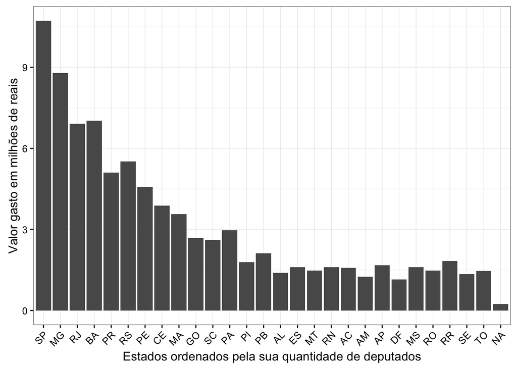

```r
gastosPorEstado = dados %>%
  select(sgUF, vlrLiquido) %>%
  group_by(sgUF) %>%
  summarise(vlrLiq = sum(vlrLiquido))

temp = merge(qtdPorEstado, gastosPorEstado)
ggplot(temp) +
  geom_bar(stat="identity", mapping = aes(x = reorder(temp$sgUF, -temp$depPorEstado),
                         y = temp$vlrLiq/1000000)) +
    labs(x='Estados ordenados pela sua quantidade de deputados', y='Valor gasto em milhões de reais') +
  theme(axis.text.x = element_text(angle = 45, hjust = 1))
```

```r
#ggplot(temp, aes(x = temp$sgUF, y = temp$vlrLiq/1000000, colour = temp$depPorEstado)) + geom_point()
```

Vamos agora escolher o mês de Janeiro para observar as diferenças de gastos entre os deputados dos dois estados e logo depois ver a distribuição destes gastos em cada mês(de Janeiro a Maio).

## Analisando a quantidade de gastos da PB em Janeiro

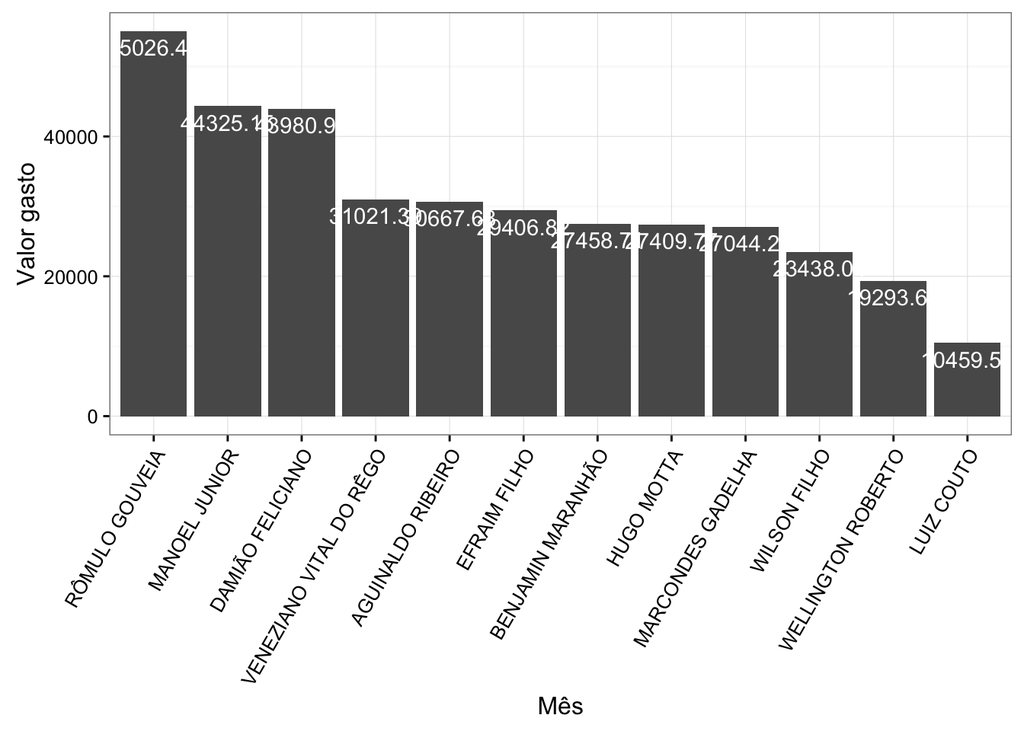

```r
gastos_pb_janeiro = dados %>%
  filter(numMes == 1, sgUF == "PB") %>%
  group_by(txNomeParlamentar) %>%
  summarise(gasto = sum(vlrLiquido))


ggplot(gastos_pb_janeiro, aes(x = reorder(txNomeParlamentar, -gasto), y = gasto)) +
  geom_bar(stat="identity") +
  geom_text(aes(label=gasto), vjust=1.5, color='white') +
  labs(x='Mês', y='Valor gasto') +
  theme(axis.text.x = element_text(angle=60, hjust = 1))
```

## Analisando a quantidade de gastos da Piauí em Janeiro

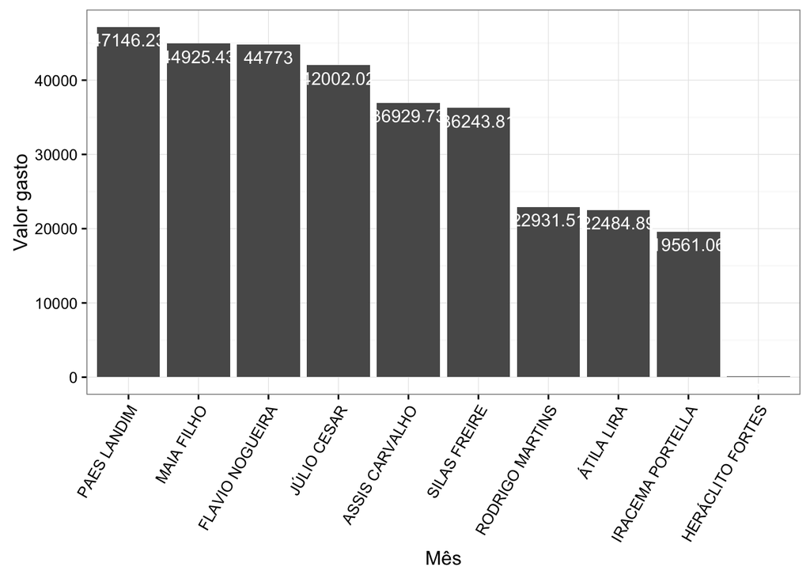

```r
gastos_pb_janeiro = dados %>%
  filter(numMes == 1, sgUF == "PI") %>%
  group_by(txNomeParlamentar) %>%
  summarise(gasto = sum(vlrLiquido))


ggplot(gastos_pb_janeiro, aes(x = reorder(txNomeParlamentar, -gasto), y = gasto)) +
  geom_bar(stat="identity") +
  geom_text(aes(label=gasto), vjust=1.5, color='white') +
  labs(x='Mês', y='Valor gasto') +
  theme(axis.text.x = element_text(angle=60, hjust = 1))
```

## Distribuição dos gastos da Paraíba por mês, de Janeiro a Maio

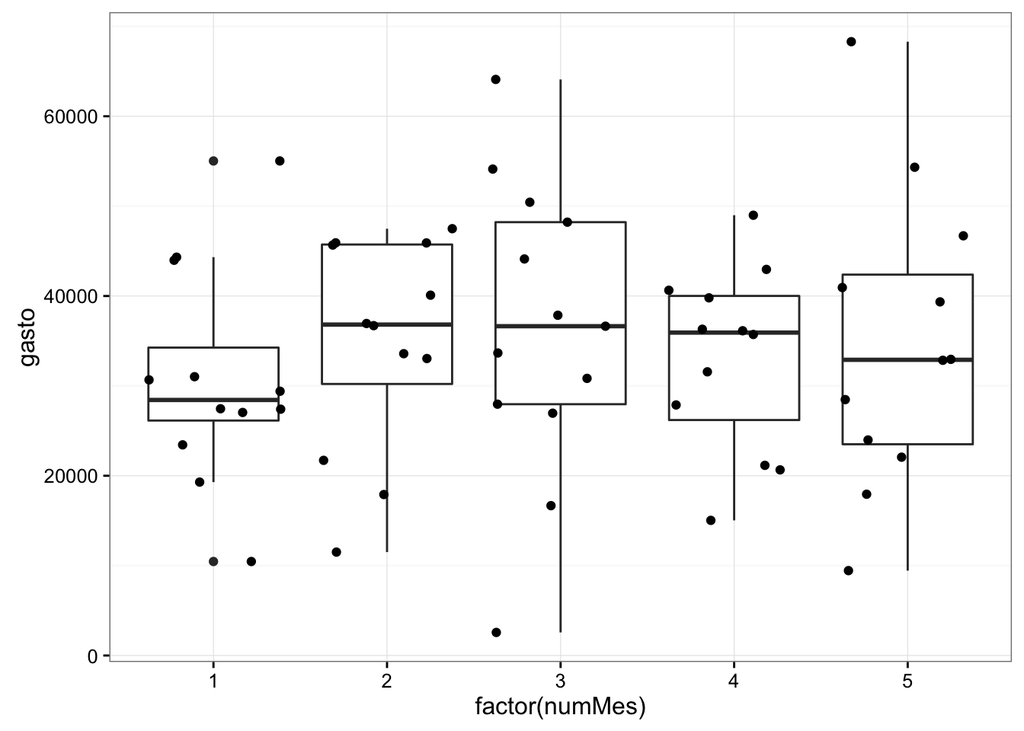

```r
gastos_por_mes_pb = dados %>%
  filter(sgUF == "PB", numMes < 6) %>%
  group_by(numMes, txNomeParlamentar) %>%
  summarise(gasto = sum(vlrLiquido))

gastos_por_mes_pb = gastos_por_mes_pb[order(gastos_por_mes_pb$numMes, gastos_por_mes_pb$gasto, decreasing = T),]

gastos_por_mes_pb_jan = gastos_por_mes_pb %>%
  filter(numMes == 1)
gastos_por_mes_pb_maio = gastos_por_mes_pb %>%
  filter(numMes == 5)

ggplot(gastos_por_mes_pb, aes(factor(numMes), gasto) ) +
  geom_boxplot() +
  geom_jitter()
```

## Summary dos meses de Janeiro e Maio para verificar outliers Com esses dados podemos ver que os valores máximo andam perto do dobro da mediana, valor mais próximo de quando comparado com todos os outros valores. Isso representa uma diferença significativa!

```r
summary(gastos_por_mes_pb_jan$gasto)
```

```
##    Min. 1st Qu.  Median    Mean 3rd Qu.    Max.
##   10460   26140   28430   30790   34260   55030
```

```r
summary(gastos_por_mes_pb_maio$gasto)
```

```
##    Min. 1st Qu.  Median    Mean 3rd Qu.    Max.
##    9444   23510   32900   34780   42380   68300
```

## Verificando outlier no mês de maio na PB(BENJAMIN MARANHÃO 68.29685)

Esse gasto de Benjamin foi escolhido pelo fato de ter ultrapassado o dobro do valor da mediana. Dentre seus gastos, o mais significativo foi na categoria DIVULGAÇÃO DA ATIVIDADE PARLAMENTAR com a empresa GRÁFICA E EDITORA MANGUEIRA LTDA, na confecção de 59000(bastante ein!?) unidades de informativo. Segue link da nota: http://www.camara.gov.br/cota-parlamentar/documentos/publ/1545/2016/5984213.pdf

```r
benjamin_maio = dados %>%
  filter(numMes == 5, nuCarteiraParlamentar == 131) #Número da carteira de BENJAMIN MARANHÃO
select(benjamin_maio[order(benjamin_maio$vlrLiquido, decreasing = T),], txtDescricao, vlrLiquido)
```

```
## # A tibble: 37 x 2
##                                                 txtDescricao vlrLiquido
##                                                        <chr>      <dbl>
## 1                       DIVULGAÇÃO DA ATIVIDADE PARLAMENTAR.   41890.00
## 2                       DIVULGAÇÃO DA ATIVIDADE PARLAMENTAR.    5000.00
## 3                              COMBUSTÍVEIS E LUBRIFICANTES.    4630.01
## 4              LOCAÇÃO OU FRETAMENTO DE VEÍCULOS AUTOMOTORES    3800.00
## 5                       DIVULGAÇÃO DA ATIVIDADE PARLAMENTAR.    3500.00
## 6  MANUTENÇÃO DE ESCRITÓRIO DE APOIO À ATIVIDADE PARLAMENTAR    3000.00
## 7  MANUTENÇÃO DE ESCRITÓRIO DE APOIO À ATIVIDADE PARLAMENTAR    1250.00
## 8                       DIVULGAÇÃO DA ATIVIDADE PARLAMENTAR.     550.00
## 9                                      Emissão Bilhete Aéreo     544.00
## 10                                                 TELEFONIA     505.90
## # ... with 27 more rows
```

## Analisando Rômulo Gouveia

Rômulo atualmente é o deputado que mais gasta na PB, então vale a pena construir um gráfico mostrando seu montante de gastos por mês e quem sabe comparar com outros como Luiz Couto(um dos que menos gasta).

```r
gastos_romulo = dados %>%
  filter(txNomeParlamentar == "RÔMULO GOUVEIA", numMes < 6) %>%
  group_by(numMes) %>%
  summarise(gasto = sum(vlrLiquido))
summary(gastos_romulo)
```

```
##      numMes      gasto
##  Min.   :1   Min.   :39349
##  1st Qu.:2   1st Qu.:47488
##  Median :3   Median :48990
##  Mean   :3   Mean   :48258
##  3rd Qu.:4   3rd Qu.:50435
##  Max.   :5   Max.   :55026
```

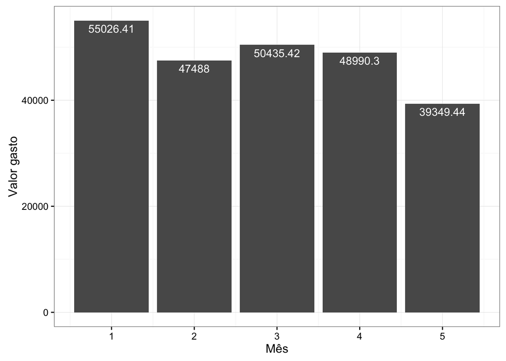

```r
ggplot(gastos_romulo, aes(x = numMes, y = gasto)) +
  geom_bar(stat="identity") +
  geom_text(aes(label=gasto), vjust=1.5, color='white') +
  labs(x='Mês', y='Valor gasto')
```

## Distribuição dos gastos do Piauí por mês, de Janeiro a Maio

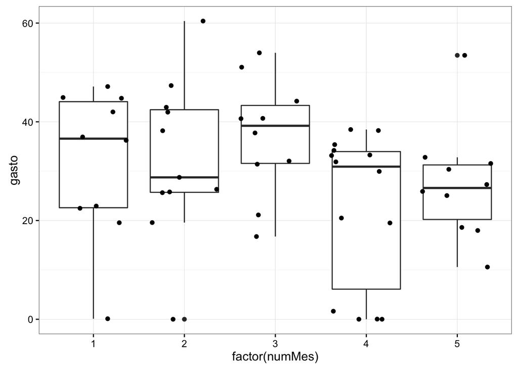

```r
gastos_por_mes_pi = dados %>%
  filter(sgUF == "PI", numMes < 6) %>%
  group_by(numMes, txNomeParlamentar) %>%
  summarise(gasto = sum(vlrLiquido)/1000)

ggplot(gastos_por_mes_pi, aes(factor(numMes), gasto) ) +
  geom_boxplot() +
  geom_jitter()
```

```r
summary(gastos_por_mes_pi)
```

```
##      numMes             txNomeParlamentar     gasto
##  Min.   :1.000   ASSIS CARVALHO  : 5      Min.   : 0.00784
##  1st Qu.:2.000   ÁTILA LIRA      : 5      1st Qu.:20.82043
##  Median :3.000   HERÁCLITO FORTES: 5      Median :31.56009
##  Mean   :3.055   IRACEMA PORTELLA: 5      Mean   :29.70300
##  3rd Qu.:4.000   JÚLIO CESAR     : 5      3rd Qu.:39.53983
##  Max.   :5.000   MAIA FILHO      : 5      Max.   :60.41241
##                  (Other)         :25
```

O piauí consegue ter um gasto abaixo da PB pelo fato de possuir maior quantidade de representantes gastando muito pouco. Vemos mais pontos próximos do 0 na distribuição do Piauí do que no da Paraíba. Então cabe a nós analisarmos a atuação destes deputados, verificar se se é uma economia feita por cada um desses representantes ou se apenas estão de licensa ou afastados do mandato. É notório que os deputados gastam bastante dinheiro em DIVULGAÇÃO DE ATIVIDADE PARLAMENTAR E COMBUSTÍVEIS E LUBRIFICANTES. Será que isso reflete uma real necessidade ou uma facilidade para desvio de verba? Valores gastos em combustível chegam a somar 6 mil reais aqui na PB, o que forneceria 1500 litros de gasolina caso essa custasse R$ 4,00 o litro, o que daria 15000 KM de autonomia para um carro que gaste 10KM/L.

## Os deputados da PB ultrapassam sua cota parlamentar?

Tendo como base o valor encontrado no site da câmara que indica que a cota parlamentar da Paraíba é de PB 42.032,56, vamos ver qual deputado se encaixa nesse limite e qual acha que esse valor está pouco para custear seus gastos.

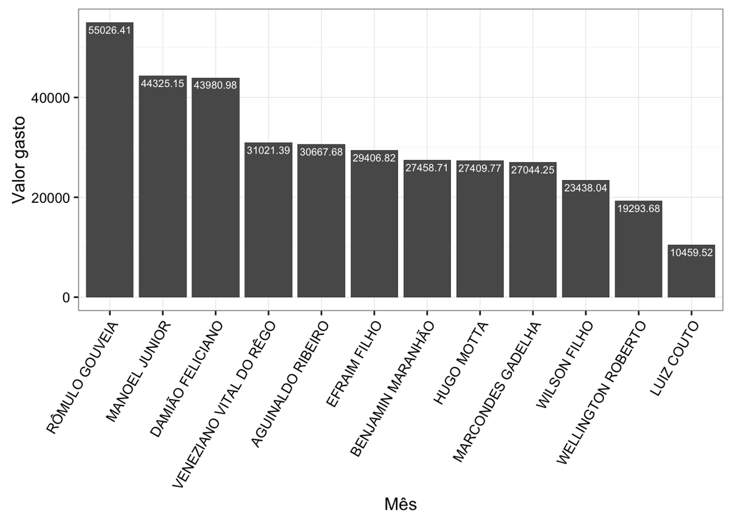

```r
gastos_pb_janeiro = dados %>%
  filter(numMes == 1, sgUF == "PB") %>%
  group_by(txNomeParlamentar) %>%
  summarise(gasto = sum(vlrLiquido))


ggplot(gastos_pb_janeiro, aes(x = reorder(txNomeParlamentar, -gasto), y = gasto)) +
  geom_bar(stat="identity") +
  geom_text(aes(label=gasto), vjust=1.5, color='white', size=2.5) +
  labs(x='Mês', y='Valor gasto') +
  theme(axis.text.x = element_text(angle=60, hjust = 1))
```

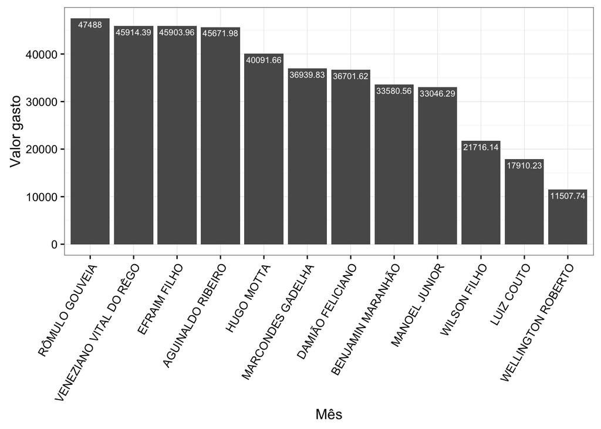

```r
gastos_pb_fev = dados %>%
  filter(numMes == 2, sgUF == "PB") %>%
  group_by(txNomeParlamentar) %>%
  summarise(gasto = sum(vlrLiquido))


ggplot(gastos_pb_fev, aes(x = reorder(txNomeParlamentar, -gasto), y = gasto)) +
  geom_bar(stat="identity") +
  geom_text(aes(label=gasto), vjust=1.5, color='white', size=2.5) +
  labs(x='Mês', y='Valor gasto') +
  theme(axis.text.x = element_text(angle=60, hjust = 1))
```

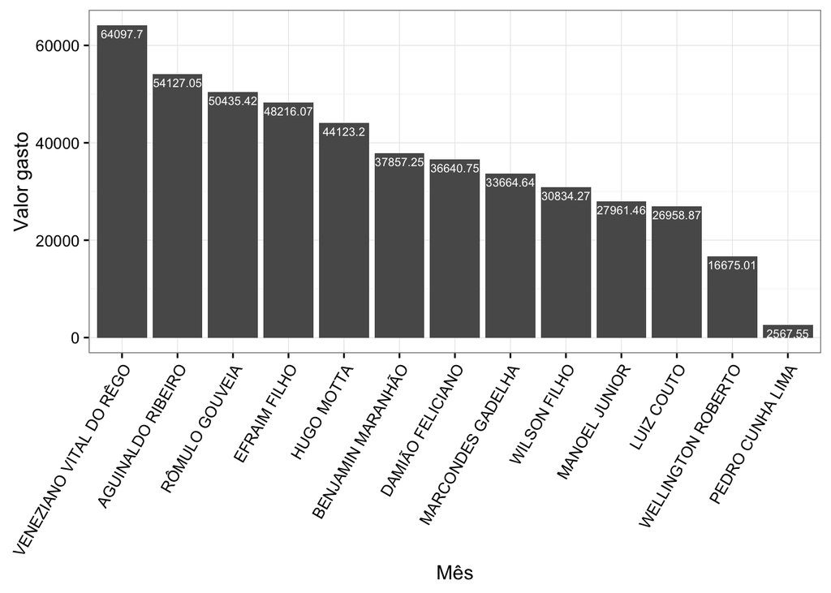

```r
gastos_pb_mar = dados %>%
  filter(numMes == 3, sgUF == "PB") %>%
  group_by(txNomeParlamentar) %>%
  summarise(gasto = sum(vlrLiquido))


ggplot(gastos_pb_mar, aes(x = reorder(txNomeParlamentar, -gasto), y = gasto)) +
  geom_bar(stat="identity") +
  geom_text(aes(label=gasto), vjust=1.5, color='white', size=2.5) +
  labs(x='Mês', y='Valor gasto') +
  theme(axis.text.x = element_text(angle=60, hjust = 1))
```

Observando os gráficos de Janeiro à Março é fácil ver que alguns não se encaixam dentro do limite da cota parlamentar para o nosso estado. De onde então sai o restante do dinheiro, do bolso de cada um deputado? Vamos estudar e encontrar essa resposta!